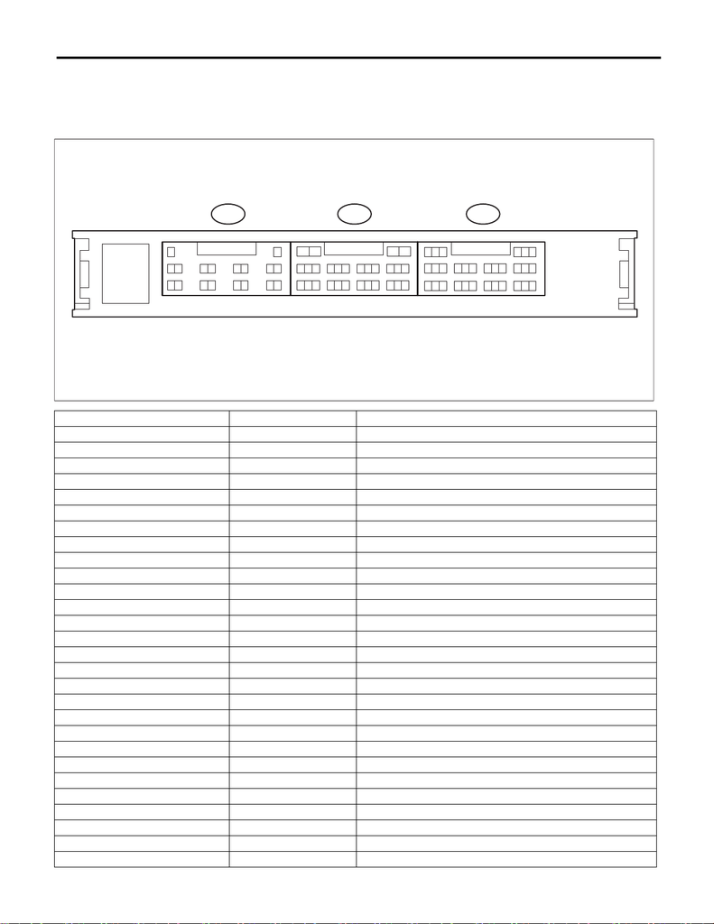

KPS(diag)-13

Control Module I/O Signal

KEYLESS ACCESS WITH PUSH BUTTON START SYSTEM (DIAGNOSTICS)

5. Control Module I/O Signal

A: ELECTRICAL SPECIFICATION

1. KEYLESS ACCESS CM

Terminal No. Terminal symbol Contents

(B572) No. 2 +B +B

(B572) No. 3 INDS Start switch indicator (green) output

(B572) No. 5 N-SW Neutral switch input

(B572) No. 7 STSW STSW output

(B572) No. 9 IG2D IG2 relay drive output

(B572) No. 10 CLUT Clutch switch input

(B572) No. 11 GND GND

(B572) No. 13 EGIO Immobilizer communication 1

(B572) No. 17 TACH Engine speed input

(B572) No. 18 STP1 Stop light switch input

(B573) No. 1 CG8B Outside rear antenna output –

(B573) No. 2 CLG8 Outside rear antenna output +

(B573) No. 5 RCO Tuner power supply

(B573) No. 8 CG7B Inside rear antenna output –

(B573) No. 9 CLG7 Inside rear antenna output +

(B573) No. 10 CG6B Inside center antenna output –

(B573) No. 11 CLG6 Inside center antenna output +

(B573) No. 15 IDW ID code box presence judgment terminal

(B573) No. 17 RDA Tuner reception data input

(B573) No. 19 RSSI Tuner reception start signal input

(B573) No. 27 TSW5 Trunk opener button input

(B573) No. 28 ACCR ACC cutoff input

(B574) No. 1 VC5 Immobilizer amplifier power supply (start switch)

(B574) No. 2 CG5B Inside front antenna output –

(B574) No. 3 CLG5 Inside front antenna output +

(B574) No. 4 ACCD ACC relay drive output

(B574) No. 5 IG IGN power supply

(B574) No. 6 IG1D IG1 relay drive output

SL-01487

1112131415161718

1

34

8

9

5567

67

2

1234

10

B572

A:

B573

B:

B574

C:

89

10111213

141516

262728

282930

16

17

18 13

14

15 10

11

12

987

321

6

5

4

[figure not shown]

KPS(diag)-14

Control Module I/O Signal

KEYLESS ACCESS WITH PUSH BUTTON START SYSTEM (DIAGNOSTICS)

Disconnect the control module connector (B572) before checking the following items.

NOTE:

If the measured value is out of standard, it is possible that the vehicle has a fault.

Disconnect the control module connector (B573) before checking the following items.

NOTE:

If the measured value is out of standard, it is possible that the vehicle has a fault.

(B574) No. 7 CODE Immobilizer signal reception (start switch)

(B574) No. 8 TSW2 Passenger’s lock sensor signal input

(B574) No. 9 TXCT Immobilizer signal transmission (start switch)

(B574) No. 10 CG2B Passenger’s antenna output –

(B574) No. 11 CLG2 Passenger’s antenna output +

(B574) No. 12 CLG1 Driver’s antenna output +

(B574) No. 13 CG1B Driver’s antenna output –

(B574) No. 14 CANH HS-CAN H

(B574) No. 15 CANL HS-CAN L

(B574) No. 16 SWIL Start switch character illumination output

(B574) No. 17 LIN LIN communication

(B574) No. 18 INDW Start switch indicator (orange) output

(B574) No. 19 POS1 Driver’s sensor drive power supply

(B574) No. 20 TSW1 Driver’s lock sensor signal input

(B574) No. 21 POS2 Passenger’s sensor drive power supply

(B574) No. 22 SEN1 Driver’s unlock sensor signal input

(B574) No. 23 SEN2 Passenger’s unlock sensor signal input

(B574) No. 24 AGND Immobilizer amplifier GND (start switch)

(B574) No. 25 P Parking position switch input

(B574) No. 26 SLP Steering lock position input

(B574) No. 27 SPD Vehicle speed signal input

(B574) No. 28 SSW1 Start switch input 1

(B574) No. 29 SLR+ Steering motor power supply signal output

(B574) No. 30 SSW2 Start switch input 2

Terminal No. Item Measuring condition Standard

(B572) No. 2 (+B) ←→ (B572) No. 11 (GND) Voltage Always 9.5 — 16 V

(B572) No. 11 (GND) ←→ Chassis ground Resistance Always Less than 1 Ω

(B574) No. 5 (IG) ←→ Chassis ground Voltage ACC ON → IG ON 1 V or less → 9 — 14 V

Terminal No. Item Measuring condition Standard

(B573) No. 15 (IDW) ←→ Chassis ground

(For C0 model only)

Continuity Always Continuity exists

Terminal No. Terminal symbol Contents

[figure not shown]

KPS(diag)-15

Control Module I/O Signal

KEYLESS ACCESS WITH PUSH BUTTON START SYSTEM (DIAGNOSTICS)

Disconnect the control module connectors (B574) and (B572) before checking the following items.

NOTE:

If the measured value is out of standard, it is possible that the vehicle has a fault.

Terminal No. Item Measuring condition Standard

(B574) No. 4 (ACCD) ←→ Chassis ground Resistance Always (20°C) 152.61 — 216.5 Ω

(B574) No. 6 (IG1D) ←→ Chassis ground Resistance Always (20°C) 50.87 — 72.17 Ω

(B572) No. 18 (STP1) ←→ Chassis ground

(Except for MT model)

Voltage Brake pedal depressed → released 11 — 14 V → 1 V

or less

(B574) No. 25 (P) ←→ Chassis ground

(Except for MT model)

Resistance Except for shift positions P → Shift position P 40 kΩ or more →

200 Ω or less

(B574) No. 27 (SPD) ←→ Chassis ground Resistance Always 30 kΩ or more

(B574) No. 28 (SSW1) ←→ Chassis ground Resistance Push button ignition switch pressed →

released

Less than 1 Ω →

10 kΩ or more

(B574) No. 29 (SLR+) ←→ Chassis ground Resistance Always 10 kΩ or more

(B574) No. 30 (SSW2) ←→ Chassis ground Resistance Push button ignition switch pressed →

released

Less than 1 Ω →

10 kΩ or more

(B574) No. 17 (LIN) ←→ Chassis ground Continuity Always Continuity does not

exist

(B574) No. 14 (CANH) ←→ Chassis ground Pulse ACC and IGN OFF, and open/close the door Pulse generation

(B574) No. 15 (CANL) ←→ Chassis ground Pulse ACC and IGN OFF, and open/close the door Pulse generation

[figure not shown]

KPS(diag)-16

Control Module I/O Signal

KEYLESS ACCESS WITH PUSH BUTTON START SYSTEM (DIAGNOSTICS)

Connect the control module connector before checking the following items.

NOTE:

If the measured value is out of standard, it is possible that the keyless access CM has a fault.

Terminal No. Item Measuring condition Standard

(B574) No. 1 (VC5) ←→

(B574) No. 24 (AGND)

Voltage 30 seconds or more have passed after the door

was opened or closed with IG OFF and without

depressing the brake pedal (except for MT

model) or clutch pedal (MT model).

1 V or less

Waveform Within 30 seconds after the push button ignition

switch is pressed with IG OFF and access key

not in the passenger room

Waveform 1

(B574) No. 2 (CG5B) ←→

(B572) No. 11 (GND)

Pulse All doors closed, ACC and IG OFF, access key

not in passenger room, touch sensor (lock) OFF

→ ON

No pulse output → Pulse out-

put detected

(B574) No. 3 (CLG5) ←→

(B572) No. 11 (GND)

Pulse All doors closed, ACC and IG OFF, access key

not in passenger room, touch sensor (lock) OFF

→ ON

No pulse output → Pulse out-

put detected

(B574) No. 4 (ACCD) ←→

(B572) No. 11 (GND)

Voltage IG OFF → ACC ON 1 V or less → 9 — 14 V

(B574) No. 6 (IG1D) ←→

(B572) No. 11 (GND)

Voltage ACC ON → IG ON 1 V or less → 9 — 14 V

(B574) No. 7 (CODE) ←→

(B574) No. 24 (AGND)

Voltage 30 seconds or more have passed after the door

was opened or closed with IG OFF and without

depressing the brake pedal (except for MT

model) or clutch pedal (MT model).

1 V or less

Waveform Turn the ignition switch to OFF and with the

access key near the push button ignition switch,

press the push button ignition switch*1

Waveform 2

(B574) No. 9 (TXCT) ←→

(B574) No. 24 (AGND)

Voltage 30 seconds or more have passed after the door

was opened or closed with IG OFF and without

depressing the brake pedal (except for MT

model) or clutch pedal (MT model).

1 V or less

Waveform Turn the ignition switch to OFF and with the

access key near the push button ignition switch,

press the push button ignition switch*1

Waveform 3

(B574) No. 10 (CG2B) ←→

(B572) No. 11 (GND)

Pulse ACC and IG OFF, all doors closed, all doors

locked by lock operation with wireless remote

control, access key not in passenger room

No pulse output → Pulse out-

put detected

(B574) No. 11 (CLG2) ←→

(B572) No. 11 (GND)

Pulse ACC and IG OFF, all doors closed, all doors

locked by lock operation with wireless remote

control, access key not in passenger room

No pulse output → Pulse out-

put detected

(B574) No. 12 (CLG1) ←→

(B572) No. 11 (GND)

Pulse ACC and IG OFF, all doors closed, all doors

locked by lock operation with wireless remote

control, access key not in passenger room

No pulse output → Pulse out-

put detected

(B573) No. 10 (CG6B) ←→

(B572) No. 11 (GND)

Pulse ACC and IG OFF, all doors closed, all doors

locked by lock operation with wireless remote

control, access key not in passenger room

No pulse output → Pulse out-

put detected

(B573) No. 11 (CLG6) ←→

(B572) No. 11 (GND)

Pulse ACC and IG OFF, all doors closed, all doors

locked by lock operation with wireless remote

control, access key not in passenger room

No pulse output → Pulse out-

put detected

(B574) No. 13 (CG1B) ←→

(B572) No. 11 (GND)

Pulse ACC and IG OFF, all doors closed, all doors

locked by lock operation with wireless remote

control, access key not in passenger room

No pulse output → Pulse out-

put detected

(B574) No. 19 (POS1) ←→

(B572) No. 11 (GND)

Voltage ACC and IG OFF, access key carried, driver’s

seat touch sensor OFF → ON

9 — 14 V → less than 2 V

(B574) No. 21 (POS2) ←→

(B572) No. 11 (GND)

Voltage ACC and IG OFF, access key carried, passen-

ger’s seat touch sensor OFF → ON

9 — 14 V → less than 2 V

[figure not shown]

KPS(diag)-17

Control Module I/O Signal

KEYLESS ACCESS WITH PUSH BUTTON START SYSTEM (DIAGNOSTICS)

(B574) No. 24 (AGND) ←→

Chassis ground

Resistance Always Less than 1 Ω

(B574) No. 25 (P) ←→

(B572) No. 11 (GND)

(Except for MT model)

Voltage Except for shift positions P → Shift position P 9 — 14 V or more → 1.5 V or

less

(B574) No. 26 (SLP) ←→

(B572) No. 11 (GND)

Voltage With ignition switch OFF and shift position P,

Steering lock → Steering unlock

11 — 14 V → 1.2 V or less

(B574) No. 27 (SPD) ←→

Chassis ground

Pulse Driving at approx. 5 km/h Pulse generation according to

vehicle speed

(approx. 5 km/h: 3.54 Hz)

(B574) No. 28 (SSW1) ←→

(B572) No. 11 (GND)

Voltage Push button ignition switch released → pressed 11 — 14 V → 1 V or less

(B574) No. 29 (SLR+) ←→

(B572) No. 11 (GND)

Voltage When the following conditions are met, the doors

are closed → opened, and steering lock motor is

driven

• Steering lock is unlocked

• IG OFF

• Shift position P

11 — 14 V (Steering lock

motor is stopped) → 1 V or

less (Steering lock motor is

driven)

(B574) No. 30 (SSW2) ←→

(B572) No. 11 (GND)

Voltage Push button ignition switch released → pressed 11 — 14 V → 1 V or less

(B573) No. 1 (CG8B) ←→

(B572) No. 11 (GND)

Pulse ACC and IG OFF, all doors closed, all doors

locked, trunk opener button OFF → ON

No pulse output → Pulse out-

put detected

(B573) No. 2 (CLG8) ←→

(B572) No. 11 (GND)

Pulse ACC and IG OFF, all doors closed, all doors

locked, trunk opener button OFF → ON

No pulse output → Pulse out-

put detected

(B573) No. 5 (RCO) ←→

(B572) No. 11 (GND)

Voltage ACC and IG OFF, access key is locked or unlock

switch OFF →

ON

1 V or less → 4.5 — 5.5 V

(B573) No. 8 (CG7B) ←→

(B572) No. 11 (GND)

Pulse All doors closed, all doors locked, trunk opened

→ closed

No pulse output → Pulse out-

put detected

(B573) No. 9 (CLG7) ←→

(B572) No. 11 (GND)

Pulse All doors closed, all doors locked, trunk opened

→ closed

No pulse output → Pulse out-

put detected

(B573) No. 19 (RSSI) ←→

(B572) No. 11 (GND)

Voltage All doors closed, all doors locked, access key is

locked or unlock switch OFF → ON

11 — 14 V → 2 V or less

(B573) No. 27 (TSW5) ←→

(B572) No. 11 (GND)

Pulse/voltage ACC and IG OFF, all doors locked, trunk opener

button OFF → ON

9 V or more → less than 2 V

(B572) No. 9 (IG2D) ←→

(B572) No. 11 (GND)

Voltage ACC ON → IG ON 1 V or less → 9 — 14 V

(B572) No. 13 (EGIO) ←→

(B574) No. 24 (AGND)

Voltage/pulse IG ON 11 to 14 V

(Waveform 4)

(B574) No. 8 (TSW2) ←→

(B572) No. 11 (GND)

Voltage ACC and IG OFF, all doors closed, all doors

locked, access key carried, passenger’s seat

touch sensor (lock) OFF → ON

9 V or more → less than 2 V

(→ 9 V or more)

(B574) No. 20 (TSW1) ←→

(B572) No. 11 (GND)

Voltage ACC and IG OFF, all doors closed, all doors

locked, access key carried, driver’s seat touch

sensor (lock) OFF → ON

9 V or more → less than 2 V

(→ 9 V or more)

(B574) No. 23 (SEN2) ←→

(B572) No. 11 (GND)

Voltage ACC and IG OFF, all doors closed, all doors

locked, access key carried, passenger’s seat

touch sensor (unlock) OFF →

ON

9 V or more → less than 2 V

(→ 9 V or more)

(B574) No. 22 (SEN1) ←→

(B572) No. 11 (GND)

Voltage ACC and IG OFF, all doors closed, all doors

locked, access key carried, driver’s seat touch

sensor (unlock) OFF → ON

9 V or more → less than 2 V

(→ 9 V or more)

(B574) No. 16 (SWIL) ←→

(B572) No. 11 (GND)

Voltage When illumination of start switch goes off, head-

light goes off after setting the illumination control

to MAX

Less than 2 V → 9 V or more

(B572) No. 17 (TACH) ←→

Chassis ground

Waveform While engine idling Pulse generation

(waveform 5)

Terminal No. Item Measuring condition Standard

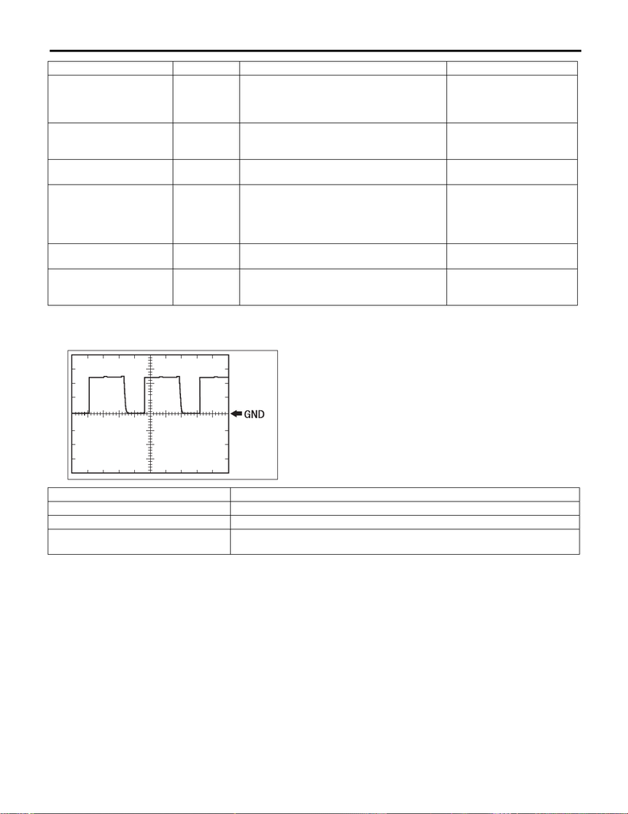

KPS(diag)-18

Control Module I/O Signal

KEYLESS ACCESS WITH PUSH BUTTON START SYSTEM (DIAGNOSTICS)

NOTE:

*1: Remove the access key battery before checking.

1. Waveform 1

(B573) No. 28 (ACCR) ←→

(B572) No. 11 (GND)

Voltage Brake pedal (except for MT model) or clutch

pedal (MT model) depressed and push button

ignition switch pressed (while cranking) →

Except when cranking

Less than 2 V → 9 V or more

(B572) No. 5 (N-SW) ←→

(B572) No. 11 (GND)

(Except for MT model)

Voltage Shift position N → other than P or N Less than 2 V → 9 V or more

(B573) No. 17 (RDA) ←→

(B572) No. 11 (GND)

Pulse All doors closed, all doors locked, access key is

locked or unlock switch OFF → ON

2 V or less → 11 — 14 V →

2 V or less

(B572) No. 7 (STSW) ←→

(B572) No. 11 (GND)

Voltage While depressing the brake pedal with the shift

lever in position P or N and with the access key

inside the vehicle (AT model), or while depress-

ing the clutch pedal (MT model), press the push

button ignition switch. (Engine start)

Less than 2 V → 9 V or more

(B572) No. 3 (INDS) ←→

(B572) No. 11 (GND)

Voltage Depress the brake pedal (except for MT model)

or clutch pedal (MT model).

9 V or more

(B574) No. 18 (INDW) ←→

(B572) No. 11 (GND)

Voltage With ACC ON or IG ON, brake pedal (except for

MT model) or clutch pedal (MT model) not

depressed

9 V or more

Terminal No. Item Measuring condition Standard

SL-01489

Item Contents

Measured terminal (B574) No. 1 (VC5) ←→ (B574) No. 24 (AGND)

Equipment setting 2 V/DIV, 200 ms/DIV

Measuring condition

Within 30 seconds after the push button ignition switch is pressed with IG OFF and

access key not in the passenger room

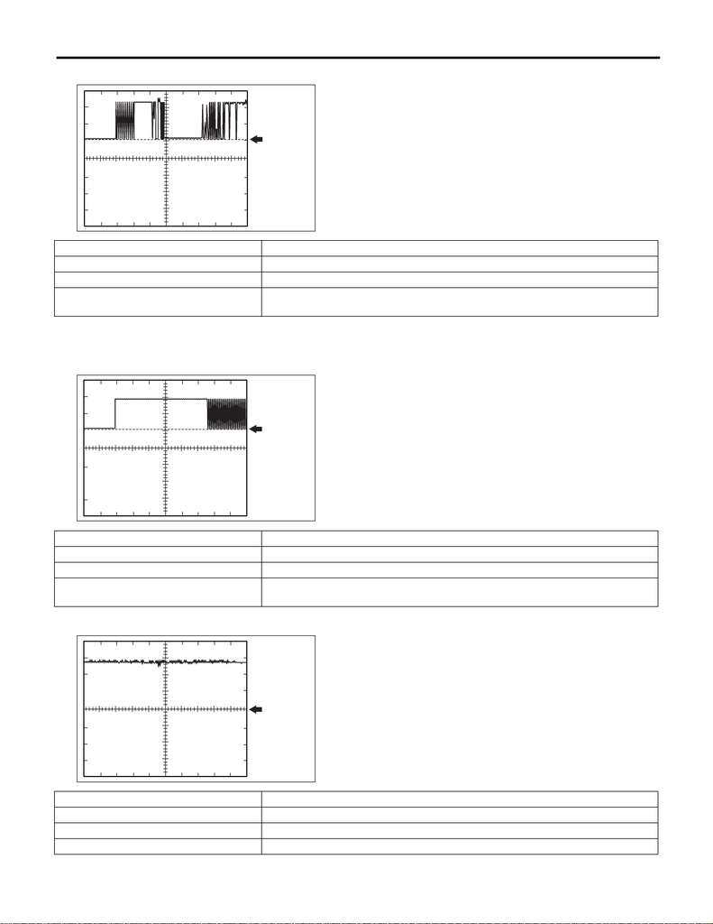

KPS(diag)-19

Control Module I/O Signal

KEYLESS ACCESS WITH PUSH BUTTON START SYSTEM (DIAGNOSTICS)

2. Waveform 2

NOTE:

*1: Remove the access key battery before checking.

3. Waveform 3

4. Waveform 4

SL-00583

GND

Item Contents

Measured terminal (B574) No. 7 (CODE) ←→ (B574) No. 24 (AGND)

Equipment setting 2 V/DIV, 20 ms/DIV

Measuring condition

Turn the ignition switch to OFF and with the access key near the push button ignition

switch, press the push button ignition switch. *1

SL-00582

GND

Item Contents

Measured terminal (B574) No. 9 (TXCT) ←→ (B574) No. 24 (AGND)

Equipment setting 2 V/DIV, 20 ms/DIV

Measuring condition

SL-02394

GND

Item Contents

Equipment setting 5 V/DIV, 100 ms/DIV

Measuring condition Ignition ON

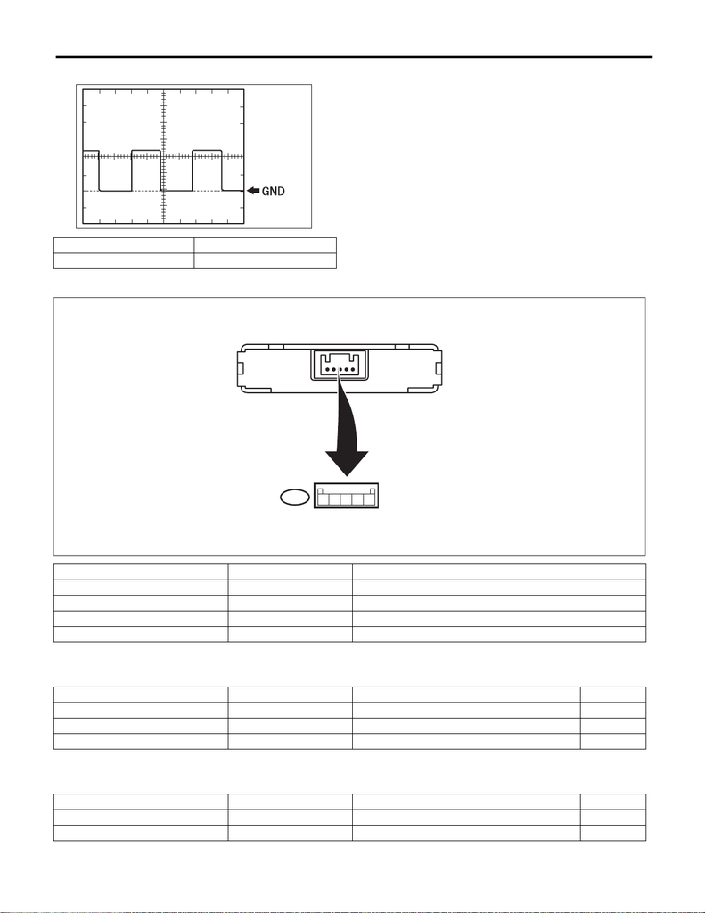

KPS(diag)-20

Control Module I/O Signal

KEYLESS ACCESS WITH PUSH BUTTON START SYSTEM (DIAGNOSTICS)

5. Waveform 5

2. ID CODE BOX

NOTE:

Disconnect the control module connector before checking the following items.

NOTE:

Connect the control module connector before checking the following items.

Item Contents

Equipment setting 5 V/DIV, 100 ms/DIV

SL-00634

Terminal No. Terminal symbol Contents

(B422) No. 1 +B +B

(B422) No. 2 LIN LIN communication

(B422) No. 4 IMO1 Immobilizer communication 1

(B422) No. 5 GND GND

Terminal No. Standard Measuring condition Item

1(+B) ←→ 5 (GND) 10 — 14 V Always Voltage

5 (GND) ←→ Chassis ground Continuity exists Always Continuity

Terminal No. Standard Measuring condition Item

4 (IMO1) ←→ 5 (GND) 0 V Ignition OFF Voltage

4 (IMO1) ←→ 5 (GND) Waveform 1 Ignition ON Voltage

B422

SL-01558

5 4 3 2 1

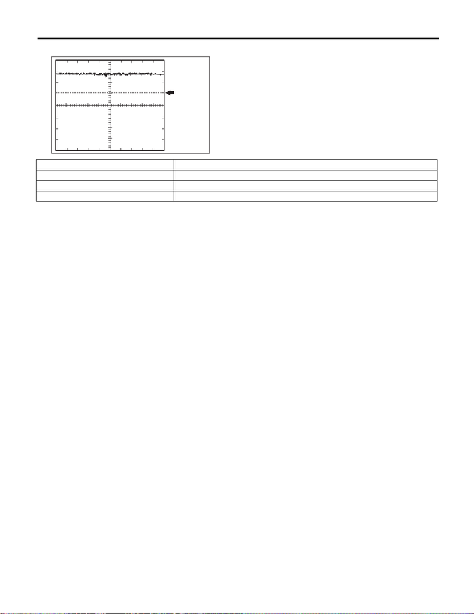

KPS(diag)-21

Control Module I/O Signal

KEYLESS ACCESS WITH PUSH BUTTON START SYSTEM (DIAGNOSTICS)

Waveform 1

3. BODY INTEGRATED UNIT

Refer to the BODY CONTROL SYSTEM (DIAGNOSTICS) for the I/O Signal of the body integrated unit. <Ref.

to BC(diag)-6, ELECTRICAL SPECIFICATION, Control Module I/O Signal.>

SL-02928

GND

Item Contents

Measured terminal 4 (IMO1) ←→ 5 (GND)

Equipment setting 5 V/DIV, 100 ms/DIV

Measuring condition Ignition ON

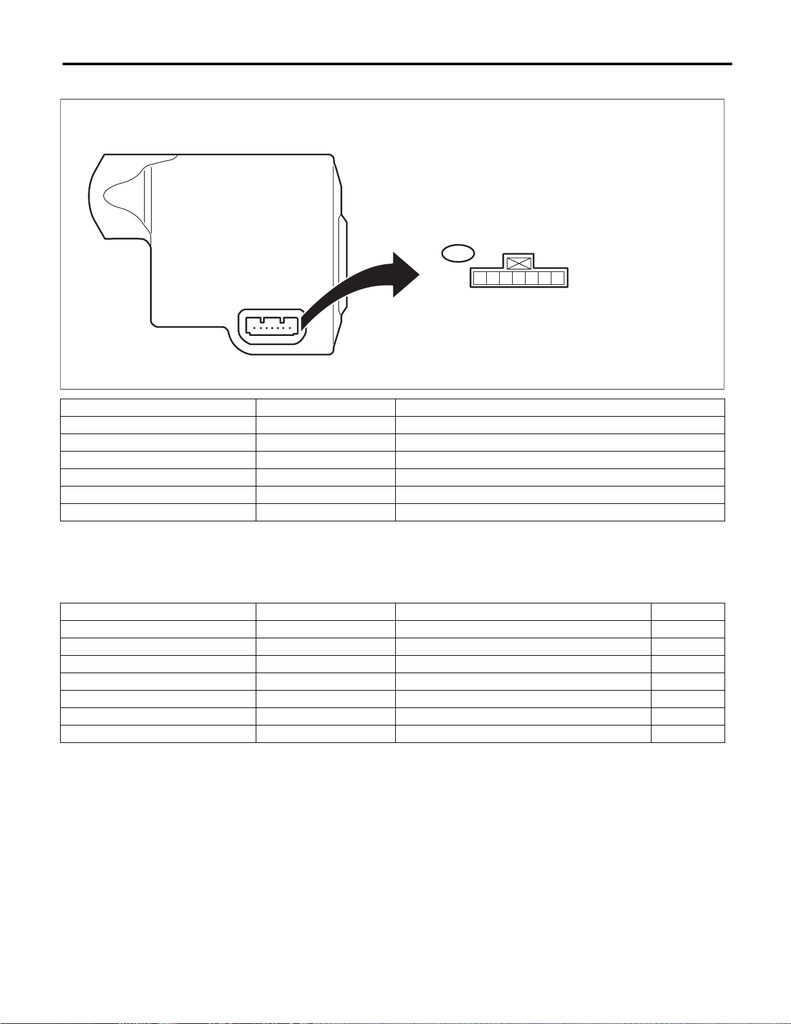

KPS(diag)-22

Control Module I/O Signal

KEYLESS ACCESS WITH PUSH BUTTON START SYSTEM (DIAGNOSTICS)

4. STEERING LOCK CM

NOTE:

Perform the following check from the back side of the connector, with the connector of the control module

connected.

If the measured value is out of standard, it is possible that the vehicle has a fault.

B: WIRING DIAGRAM

Refer to “Keyless Access System” in the wiring diagram. <Ref. to WI-275, WIRING DIAGRAM, Keyless Ac-

cess System.>

Terminal No. Terminal symbol Contents

(B424) No. 1 GND GND

(B424) No. 3 SLR+ Steering lock motor drive power supply

(B424) No. 4 SLP Unlock position output

(B424) No. 5 LIN LIN communication

(B424) No. 6 IG2 IGN power supply

(B424) No. 7 B +B

Terminal No. Standard Measuring condition Item

1 (GND) ←→ Chassis ground Continuity exists Always Continuity

— — — —

3 (SLR+) ←→ Chassis ground 10 — 14 V → 1 V or less Motor not operating → Motor operating Voltage

4 (SLP) ←→ Chassis ground 10 — 14 V → 1 V or less Lock → Unlock Voltage

5 (LIN) Input/output signal — —

6 (IG2) ←→ Chassis ground 10 — 14 V Ignition ON Voltage

7 (B) ←→ Chassis ground 10 — 14 V Always Voltage

SL-00596

B424

7654321